# Analysis of Officer Delke’s Traffic Stops and Searches

Peter Vielehr

9/29/2018

Non-random, unadjusted data tells the story of the data collection, not the reality from which it was drawn.

Officer Delke shot Daniel Hambrick on July 26, 2018. He was hired by MNPD on July 1, 2016 and on December 28, 2016 was assigned to the East Precinct. Data for this analysis comes from public records requests of MNPD’s Form 252 database. Following each traffic stop, officers are required to submit a 252 form and the record is collected in the database. Additional employee data come from an officer demographic and assignment database received through a public records request covering 2010 through the end of 2017.

The first traffic stop record for Officer Delke is from March 4, 2017 while assigned to the South Precinct. Following his assignment to East Precinct (from December 28, 2016 to February 24, 2017), Officer Delke spent two month in South Precinct (February 25, 2017 to April 20, 2017) before moving to North Precinct and finishing out 2017. On January 7, 2018, Officer Delke was assigned to East Precinct.

Between March 4, 2017 and July 26, 2018, Officer Delke conducted 510 traffic stops (not including his stop of Daniel Hambrick). Of these, 364 (71.4%) were of black drivers and 118 (23.1%) were of white drivers. He conducted 45 searches (8.8% of all stops) and found evidence 15 times (12 were drugs, 0 weapons, and 6 other evidence) for a hit-rate of 33.3%. When comparing searches by race, he conducted 39 searches of black drivers (86.7% of total searches; 10.7% of all black drivers stopped) and three searches of white drivers (6.7% of total searches; 2.5% of all white drivers stopped). He found evidence in 13 searches of black drivers (33.3%) and one white driver.

These statistics cannot be interpreted in isolation. A large research literature on racial profiling shows that proving racial bias on the part of an individual using aggregate data is not possible. Researchers have developed ways to infer whether racial bias may be taking place but there are many methodological challenges in doing so. A central concern is the definition of racial profiling or racial bias. Profiling and bias refer to an individual’s decision making process when deciding who to pull over (Glaser 2014). The MNPD policy manual defines racially biased policing as using race as the sole reason for initiating a police action. Race can be a reason for making a stop as long as another legal reason for making the stop is stated. If a legal reason for making a stop exists, it can be used as a pretext to initiate a stop and investigate whether other violations are occurring.

There are also different methodological issues in analyzing the decision to make a traffic stop and the decision to search a vehicle. For making a stop, the risk that an individual is pulled over depends on the composition of the driving population in the area the stop is made and the driving behavior of the drivers. This is referred to as the benchmarking or denominator problem (Fridell 2004). Many of the neighborhoods where Officer Delke worked have high populations of black residents, some as high as 80-90% black. Therefore, the driving population in those areas is likely to be primarily black people and the location of traffic stops needs to be taken into account in analyses. Additionally, determining whether a rate of traffic stops is justifiable is a challenging task. One strategy to get around using benchmarks from outside data sources (like the US Census) is to use an “internal benchmark.” An internal benchmark is calculated based on all officers that patrol a given area. This gives the normative rate which can then show whether a specific officer is outside of the norm for all officers. If an officer shows a consistent disparity compared to other officers across many zones, he or she may be using biased criteria when deciding to stop a vehicle.

When analyzing the decision to search at a stop, the underlying population at risk of a search is known since you have to be stopped in order to get searched. The rate of searches is a bit more straight forward than decisions to stop a vehicle, but there are still limitations to this (Knowles, Persico, and Todd 1999; Rojek, Rosenfeld, and Decker 2012). Finally, hit rates show whether different levels of suspicion are being applied to groups (Persico and Todd 2006). Categorical differences, when found, show that a group has a lower or higher threshold used to initiate a search, though some limitations are discussed in the research literature (Simoiu, Corbett-Davies, and Goel 2016).

# Traffic Stops

Table 1 shows Officer Delke’s total stops, stops of black drivers, and percent of drivers who were black in each zone. For all officers, the average percentage and the standard deviation of the mean is shown. Finally, officer Delke’s z-scores show how far his rate is from the mean taking into account the variability in each zone.

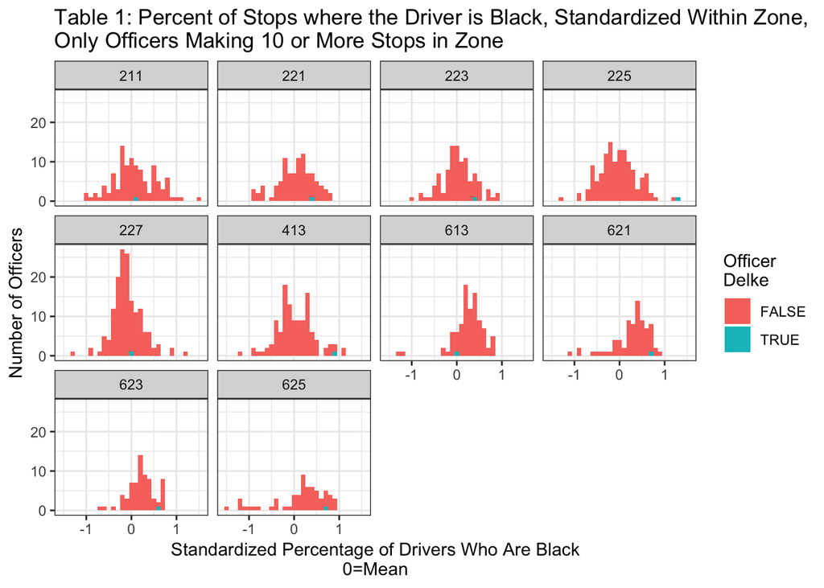

| Zone | Officer Delke Total Stops | Officer Delke Black Drivers Stopped | Officer Delke % Black | All Officers Mean Black % | All Officers SD % Black Stops | Delke Z-Score<sup>a</sup> |
| --- | --- | --- | --- | --- | --- | --- |
| 211 | 41 | 23 | 56.1 | 53.5 | 16.1 | 0.15 |
| 221 | 179 | 126 | 70.4 | 58.5 | 14.6 | 0.37 |
| 223 | 95 | 68 | 71.6 | 59.2 | 12.5 | 0.39 |
| 225 | 10 | 9 | 90.0 | 44.6 | 14.2 | 1.30 |
| 227 | 35 | 14 | 40.0 | 37.3 | 10.5 | -0.01 |
| 413 | 15 | 11 | 73.3 | 43.9 | 14.6 | 0.85 |
| 613 | 16 | 12 | 75.0 | 84.4 | 10.3 | -0.05 |
| 621 | 27 | 23 | 85.2 | 70.8 | 15.0 | 0.66 |
| 623 | 34 | 33 | 97.1 | 86.4 | 8.7 | 0.57 |
| 625 | 13 | 12 | 92.3 | 69.5 | 22.2 | 0.75 |

<sup>a</sup> Number of Standard Deviations From Mean

# Searches

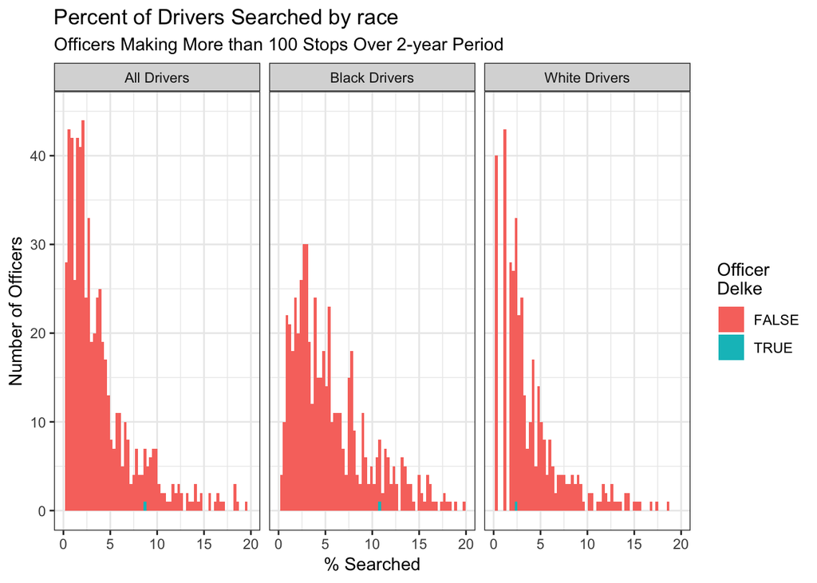